```python
import tensorflow as tf
import keras
from keras.preprocessing.image import ImageDataGenerator
from keras import layers, regularizers
import matplotlib.pyplot as plt
from sklearn.metrics import confusion_matrix
import pandas as pd
import PIL
from PIL import ImageDraw, ImageFont
import os
import numpy as np
from collections import Counter
```

# Scanning an Image for Chess Pieces

## Goal: Using My Piece Classifier - scan a sparce chess board for pieces

# First Strategy:

The first strategy for examining a board is to break the board into boxes representing each square, and examining each box separately.

For this prototype - I've (exhaustively) manually formatted the boxes.

This Strategy did not work very well - and is very limited. For a better strategy - skip to Second Strategy Section below

```python
# Locations of each square.  Format is (left, top, width, height)
locations = {
    "A1":[108,392,169,207],
    "B1":[237,392,155,207],
    "C1":[361,392,147,207],
    "D1":[486,393,136,207],
    "E1":[608,392,130,207],
    "F1":[724,391,143,207],
    "G1":[842,390,145,207],
    "H1":[953,388,162,207],

    "A2":[142,318,157,205],
    "B2":[264,316,148,207],
    "C2":[380,316,137,207],
    "D2":[495,311,132,207],
    "E2":[609,311,128,207],
    "F2":[720,310,130,207],
    "G2":[827,311,140,207],
    "H2":[936,309,147,207],

    "A3":[176,254,144,199],
    "B3":[289,254,135,199],
    "C3":[398,251,128,199],
    "D3":[505,250,122,199],
    "E3":[614,248,117,199],
    "F3":[716,247,126,199],
    "G3":[817,245,131,199],
    "H3":[919,245,138,199],

    "A4":[207,190,134,196],
    "B4":[309,190,127,196],
    "C4":[415,193,118,196],
    "D4":[516,192,112,196],
    "E4":[616,192,110,196],
    "F4":[712,189,116,196],
    "G4":[809,188,122,196],
    "H4":[904,188,126,196],

    "A5":[230,140,124,185],
    "B5":[328,141,120,185],
    "C5":[425,140,114,185],
    "D5":[520,140,111,185],
    "E5":[619,137,105,185],
    "F5":[709,138,111,185],
    "G5":[801,136,115,185],
    "H5":[891,135,122,185],

    "A6":[248,110,122,176],
    "B6":[344,109,114,176],
    "C6":[439,106,107,176],
    "D6":[528,105,103,176],
    "E6":[618,160,100,176],
    "F6":[707,104,102,176],
    "G6":[794,104,107,176],
    "H6":[879,103,114,176],

    "A7":[273,72,110,170],
    "B7":[361,72,107,170],
    "C7":[447,102,69,170],
    "D7":[533,68,99,170],
    "E7":[621,67,95,170],
    "F7":[703,67,100,170],
    "G7":[786,64,104,170],
    "H7":[869,66,106,170],

    "A8":[288,36,106,164],
    "B8":[374,34,101,164],
    "C8":[455,36,101,164],
    "D8":[539,33,96,164],
    "E8":[619,32,93,164],
    "F8":[702,30,93,164],
    "G8":[779,32,98,164],
    "H8":[857,29,104,164]
}
```

```python
#Load the Model
model = keras.models.load_model("ThirdAttempt")
```

```python
#Load the image
images_folder = "SparseBoards"
img_height, img_width = 721, 1280
targ_height, targ_width = 100, 90

image = PIL.Image.open(os.path.join(images_folder, "first.jpg"))

labels={
    0:"B-Bishop",
    1:"B-King",
    2:"B-Knight",
    3:"B-Pawn",
    4:"B-Queen",
    5:"B-Rook",
    6:"None",
    7:"W-Bishop",
    8:"W-King",
    9:"W-Knight",
    10:"W-Pawn",
    11:"W-Queen",
    12:"W-Rook",
}

predictions = []

for square, pos in locations.items():
    left = pos[0]
    top = pos[1]
    right = pos[0] + pos[2]
    bottom = pos[1] + pos[3]
    piece = image.crop((left, top, right, bottom))
    piece = piece.resize((targ_width, targ_height))
    piece_array = np.array(piece, dtype=np.float64)
    piece_array /= 256
    piece_array = piece_array.reshape(1, 100, 90, 3)
    pred = model.predict(piece_array)[0]
    pred = pred.tolist()
    predictions.append(labels[pred.index(max(pred))])

count = Counter(predictions)
```

```
Counter({'None': 40,
         'B-Rook': 2,
         'W-Rook': 2,
         'W-Bishop': 2,
         'B-Knight': 2,
         'W-Pawn': 4,
         'B-Bishop': 3,
         'B-Pawn': 2,
         'W-King': 7})
```

This strategy performs extremely poorly. It identifies a total of 24 pieces, where only 8 are present.

The extra pieces are due to the large amount of overlap between neighboring squares - so a rook that is fully present in one box will also partially show up in adjacent boxes.

Despite using a classifier with 82% test accuracy, this strategy is pretty bad

## Strategy 2: Scanning the Image

Now we'll scan the image a little more dynamically - adapting the object detection strategy laid out on 486 of "Hand-On Machine Learning with Scikit_learn, Keras, and Tensorflow" (Geron).

The first step is to scan the image left-to-right, top-to-bottom to identify bounding boxes that likely contain an object.

Note that we are using some prior knowledge about the size of the pieces in the image - so we do not need to repeatedly rescan the image with different sizes of bounding boxes.

```python
# Load the image
cropped_space = "SparceCropped"
image = PIL.Image.open(os.path.join(cropped_space, "first.jpg"))

# Load the model (it's called thirdAttempt - but it's really about the 30th)
model = keras.models.load_model("ThirdAttempt")

# Define image size
im_width, im_height = image.size

# Size of bounding box
b_height = 210
b_width = 170

# Starting location
top, left = 0, 0

# Storage for the prediction for each bounding box. Will be a 2d list
predictions = []

# Scan rows until you hit bottom of image
while top + b_height < im_height:

    # Append a row to our prediction
    row_predictions =list()
    predictions.append(row_predictions)

    left = 0
    # Scan images until you hit end of row
    while left + b_width < im_width:

        # Crop the appropriate bouding box
        im = image.crop((left, top, left+b_width, top + b_height))
        im = im.resize((targ_width, targ_height))
        im_array = np.array(im, dtype=np.float64)
        im_array /= 256
        im_array = im_array.reshape(1, 100, 90, 3)

        # Create and store prediction
        pred = model.predict(im_array)[0]
        pred = pred.tolist()
        row_predictions.append(pred)

        left += b_width/5

    top += b_height/5

# Bookkeepping labels
labels={
    0:"B-Bishop",
    1:"B-King",
    2:"B-Knight",
    3:"B-Pawn",
    4:"B-Queen",
    5:"B-Rook",
    6:"None",
    7:"W-Bishop",
    8:"W-King",
    9:"W-Knight",
    10:"W-Pawn",
    11:"W-Queen",
    12:"W-Rook",
}

# Printing colors
colors={
    0: "red",
    1:"blue",
    2:"green",
    3:"orange",
    4:"yellow",
    5:"purple",
    7: "red",
    8:"blue",
    9:"green",
    10:"orange",
    11:"yellow",
    12:"purple"
}
```

We have now used the classifier to create predictions for each bounding box. We can filter out bounding boxes for which no piece was detected - or for which the detection confidence was very low:

```python
# Initialize a set of blank predictions
# Prediction format is (index, confidence, flag) - where index is the predicted piece(0-12, where 6 is a non-piece)
#      confidence is a percentage, and flag is used for logistics later and is bad design
piece_pred = [[[6, 0, False] for i in range(len(row))] for row in predictions]

# Create a 2d array of tuples.  Tuple of form (index, probability) of the piece-index predicted and the confidence
for index, piece in labels.items():

    # Iterate over the box positions
    for y, row in enumerate(predictions):
        for x, img in enumerate(row):

            # Check if the box has a relatively certain object
            if img[index] < .7:
                continue

            # Append the index of the piece and the confidence
            piece_pred[y][x] = [index, img[index], False]
```

The predictions now reflect some modest amount of confidence - but the bounding boxes still overlap significantly, as we see below:

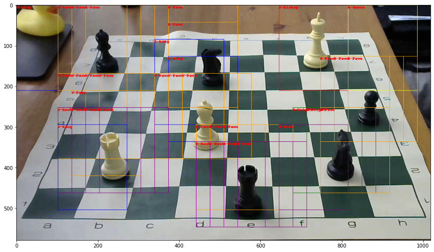

```python
with PIL.Image.open(os.path.join(cropped_space, "first.jpg")) as im:

#Iterate over piece predictions
    for y, row in enumerate(piece_pred):
        for x, img in enumerate(row):
            # Skip any Predictions of non-pieces
            if piece_pred[y][x][0] == 6:
                continue
            # Draw the box and label it
            draw = ImageDraw.Draw(im)
            left = x*b_width/5
            top = y*b_height/5
            right = left + b_width
            bottom = top + b_height
            draw.rectangle((left, top, right, bottom), outline=colors[piece_pred[y][x][0]])
            draw.text((left, top), labels[piece_pred[y][x][0]], fill="red")

    # plt the result image
    plt.subplots(figsize=(15,9))
    plt.imshow(im)
```

To fix the overlapping bounding boxes - we will iteratively erase bounding boxes. We start with the highest-confidence prediction bounding box, and erase any neighboring boxes it largely overlaps with. We repeat until there are no more troubling overlaps.

We define a function to detect the presence of overlaps:

```python
def has_overlaps(preds):
    """ Goes through predictions to see if nearby boxes are making same prediction"""
    for y, row in enumerate(preds):
        for x, box in enumerate(row):
            # If square has no prediction (indicated by 6), skip it
            if box[0] == 6:
                continue

            # Otherwise look at neighboring (w/in range 2) boxes for overlaps
            for y_neighbs in range(max(0, y-2), min(len(preds), y+3)):
                for x_neighbs in range(max(0, x-2), min(len(row), x+3)):
                    if x == x_neighbs and y==y_neighbs:
                        continue
                    if preds[y_neighbs][x_neighbs][0] == box[0]:
                        return True
    return False
```

And we iteratively erase bounding boxes

```python
while has_overlaps(piece_pred):

    #Find the max confidence:
    max_x, max_y, max_conf = 0,0,0
    for y, row in enumerate(piece_pred):
        for x, box in enumerate(row):
            if not piece_pred[y][x][2] and piece_pred[y][x][1] > max_conf:
                max_conf = piece_pred[y][x][1]
                max_x, max_y = x,y

    piece_pred[max_y][max_x][2] = True

    # If it's a none-square - skip it:
    if piece_pred[max_y][max_x][0] == 6:
        continue

    # Look at the nieghboring boxes of the highest confidence box
    for y_neighbs in range(max(0, max_y-2), min(len(piece_pred), max_y+3)):
        for x_neighbs in range(max(0, max_x-2), min(len(piece_pred[0]), max_x+3)):
            # Skip the current box
            if max_x == x_neighbs and max_y==y_neighbs:
                continue

            # Erase the less-confident neighbor boxes
            piece_pred[y_neighbs][x_neighbs] = [6, 0, True]
```

We can now take a second look at the results.

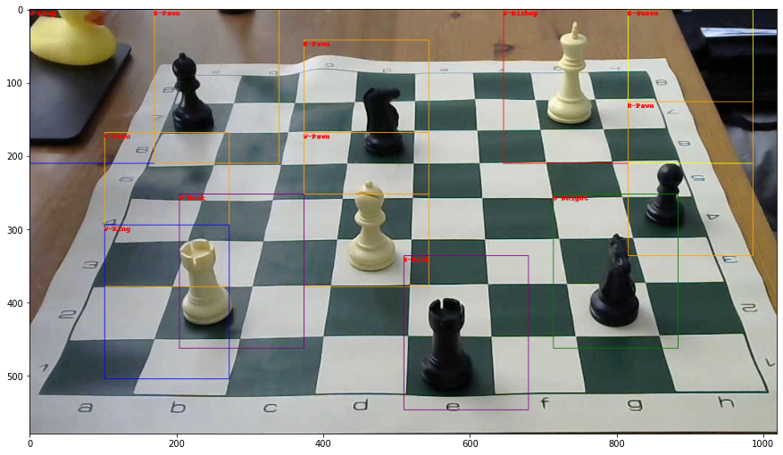

```python
with PIL.Image.open(os.path.join(cropped_space, "first.jpg")) as im:

#     Iterate over piece predictions
    for y, row in enumerate(piece_pred):
        for x, img in enumerate(row):
            # Skip any Predictions of non-pieces
            if piece_pred[y][x][0] == 6:
                continue
            # Draw the box and label it
            draw = ImageDraw.Draw(im)
            left = x*b_width/5
            top = y*b_height/5
            right = left + b_width
            bottom = top + b_height
            draw.rectangle((left, top, right, bottom), outline=colors[piece_pred[y][x][0]])
            draw.text((left, top), labels[piece_pred[y][x][0]], fill="red")
    # plt the result image
    plt.subplots(figsize=(15,9))
    plt.imshow(im)
```

The result image is much nicer!

### Analysis

The classifier's accuracy is a huge limiting factor. As we can see above - it gets several predicitons very wrong, and we can observe the tendency to overpredict pawns in particular.

As a delightful side effect, it is determined to classify the rubber duck as a white king!

The classifier was also improperly trained on detecting non-pieces. It did not get nearly enough training images to learn to ignore pieces that were only partially in frame. It also did not get enough training on images that were not of the chess board at all - so both the upper left and upper right portions of the image are falsely detected as images.